# GE461 - Introduction to the Data Science - Project

Berk Büyükdurak - 21301089

İlknur Baş - 21601847

### Connecting the Database

```r
con <- dbConnect(SQLite(), "data/dodgers.sqlite")

events <- tbl(con, "events") %>%
  collect() %>%
  mutate(day_of_week = factor(day_of_week, levels = c("Monday", "Tuesday", "Wednesday", "Thursday", "Friday", "Saturday", "Sunday")),
         month = factor(month, levels = c("APR","MAY","JUN","JUL","AUG","SEP","OCT")),
         temp = round((temp - 32)*5/9),
         bobblehead = ifelse(bobblehead=="YES", 1, 0)) # temp is converted from F to C.)

dataSet <- dbReadTable(con, "events")

dbDisconnect(con)
```

### Exploring the Relation Between Skies - Attend and Bobblehead Promotion

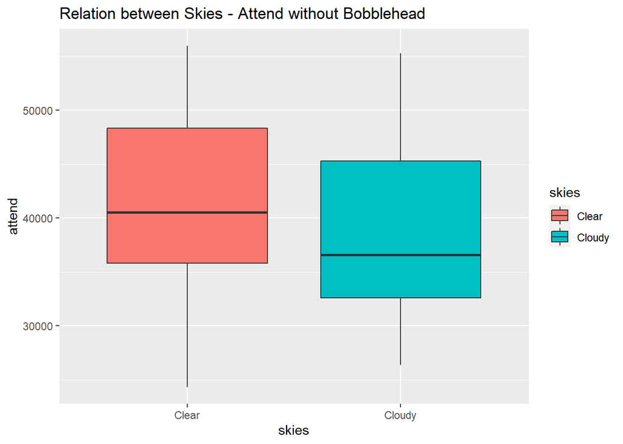

```r
skies_attend <- ggplot(dataSet, aes(skies, attend)) +
  geom_boxplot(aes(fill = skies)) +
  ggtitle("Relation between Skies - Attend without Bobblehead")

skies_attend
```

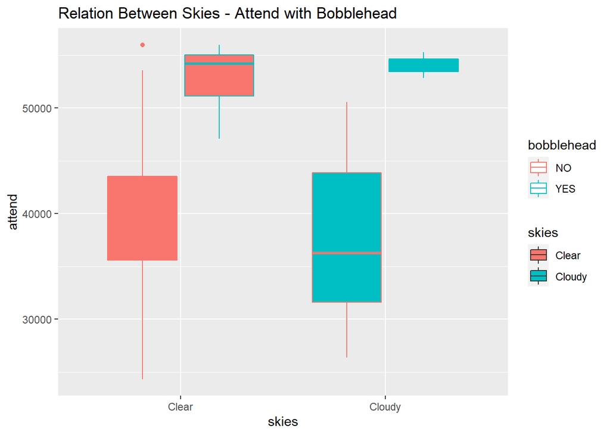

```r
skies_attend_bobble <- ggplot(dataSet, aes(skies, attend)) +
  geom_boxplot(aes(fill = skies, color = bobblehead)) +
  ggtitle("Relation Between Skies - Attend with Bobblehead")

skies_attend_bobble
```

### Exploring the Relation Between Month - Attend and Bobblehead Promotion

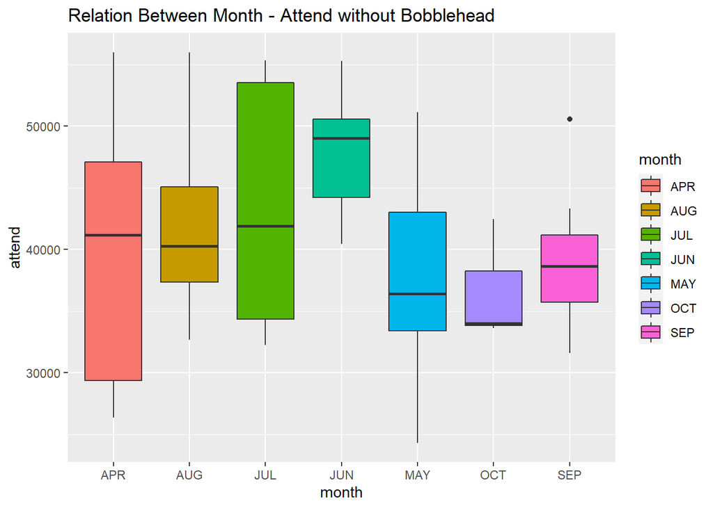

```r
month_attend <-ggplot(dataSet, aes(month, attend)) +
  geom_boxplot(aes(fill = month)) +
  ggtitle("Relation Between Month - Attend without Bobblehead")

month_attend
```

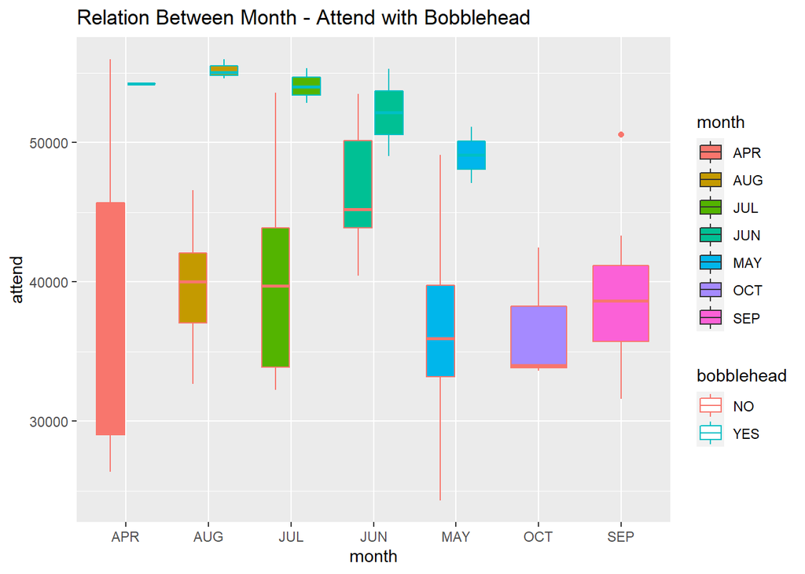

```r
month_attend_bobblehead <- ggplot(dataSet, aes(month, attend)) +
  geom_boxplot(aes(fill = month, color = bobblehead)) +
  ggtitle("Relation Between Month - Attend with Bobblehead")

month_attend_bobblehead
```

### Exploring the Relation Between Opponent - Attend and Bobblehead Promotion

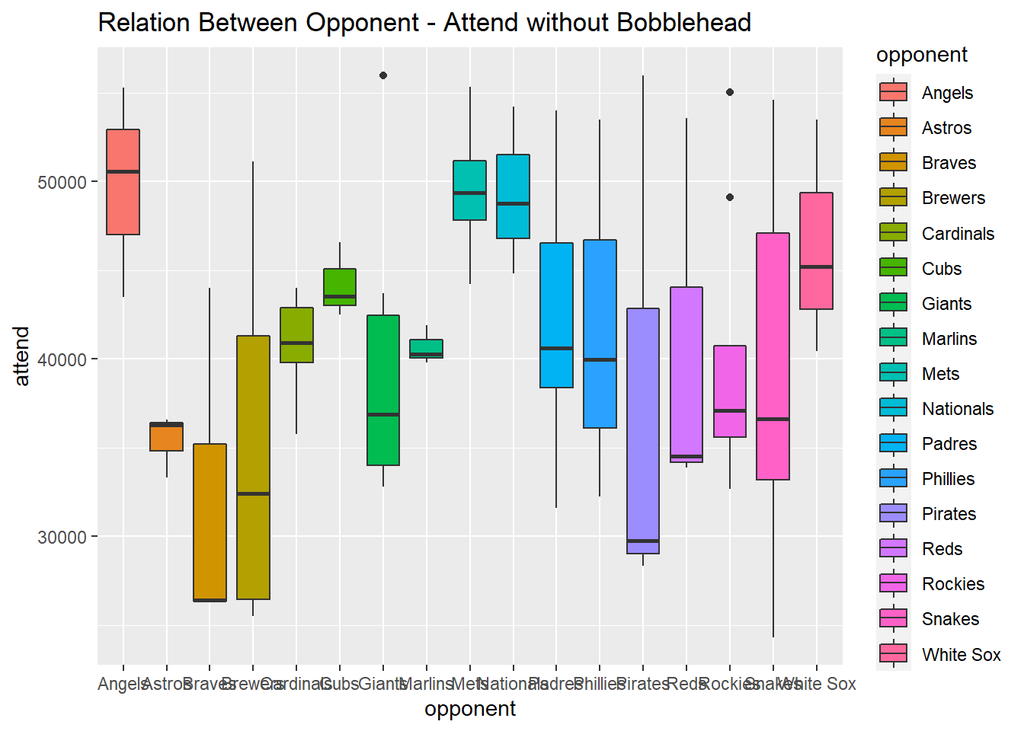

```r
opponent_attend <- ggplot(dataSet, aes(opponent, attend)) +
  geom_boxplot(aes(fill = opponent)) +
  ggtitle("Relation Between Opponent - Attend without Bobblehead")

opponent_attend
```

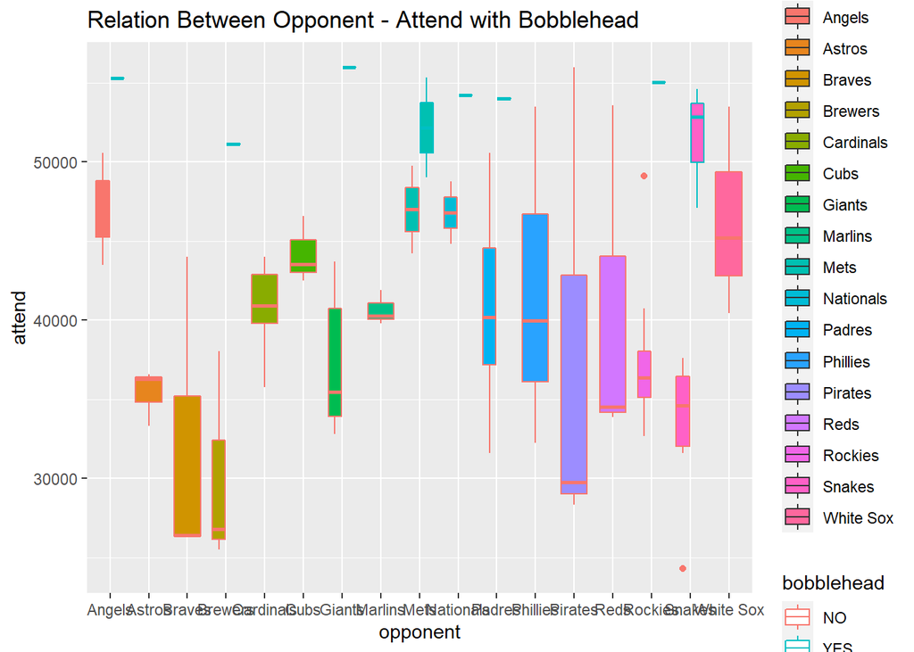

```r
opponent_attend_bobblehead <- ggplot(dataSet, aes(opponent, attend))+
  geom_boxplot(aes(fill = opponent, color = bobblehead)) +
  ggtitle("Relation Between Opponent - Attend with Bobblehead")

opponent_attend_bobblehead
```

### Exploring the Relation Between Fireworks - Attend and Bobblehead Promotion

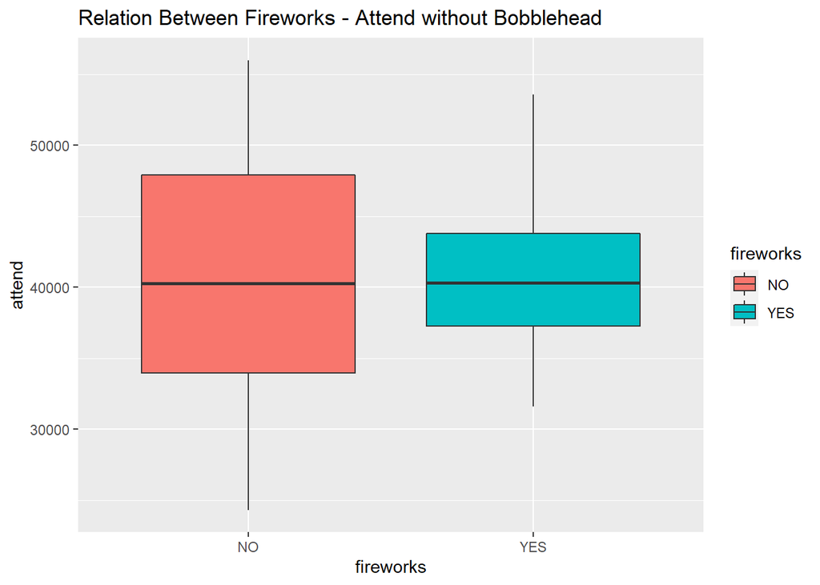

```r
fireworks_attend <- ggplot(dataSet, aes(fireworks, attend)) +
  geom_boxplot(aes(fill = fireworks)) +
  ggtitle("Relation Between Fireworks - Attend without Bobblehead")

fireworks_attend
```

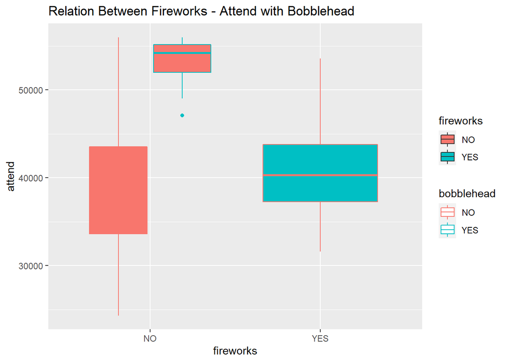

```r
fireworks_attend_bobblehead <- ggplot(dataSet, aes(fireworks, attend)) +
  geom_boxplot(aes(fill = fireworks, color = bobblehead)) +
  ggtitle("Relation Between Fireworks - Attend with Bobblehead")

fireworks_attend_bobblehead
```

### Exploring the Relation Between Shirt - Attend and Bobblehead Promotion

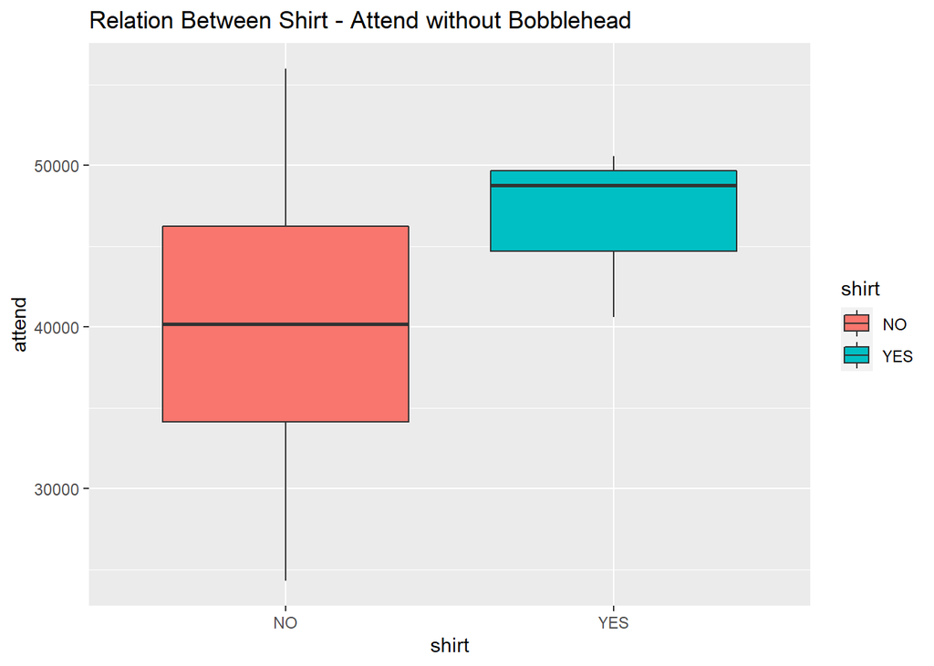

```r
shirt_attend <- ggplot(dataSet, aes(shirt, attend)) +
  geom_boxplot(aes(fill = shirt)) +
  ggtitle("Relation Between Shirt - Attend without Bobblehead")

shirt_attend
```

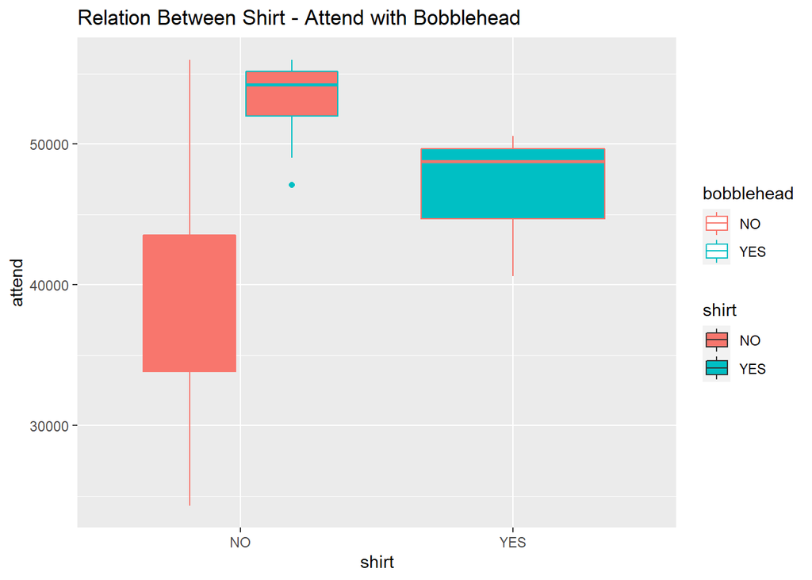

```r
shirt_attend_bobblehead <- ggplot(dataSet, aes(shirt, attend)) +
  geom_boxplot(aes(fill = shirt, color = bobblehead)) +
  ggtitle("Relation Between Shirt - Attend with Bobblehead")

shirt_attend_bobblehead
```

### Exploring the Relation Between Cap - Attend and Bobblehead Promotion

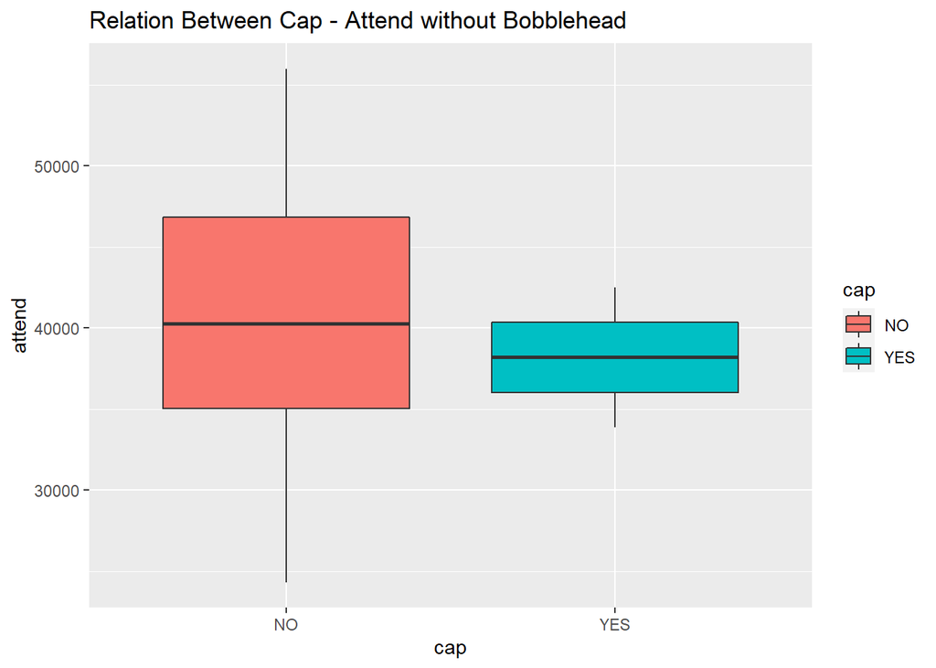

```r
cap_attend <- ggplot(dataSet, aes(cap, attend)) +
  geom_boxplot(aes(fill = cap)) +
  ggtitle("Relation Between Cap - Attend without Bobblehead")

cap_attend
```

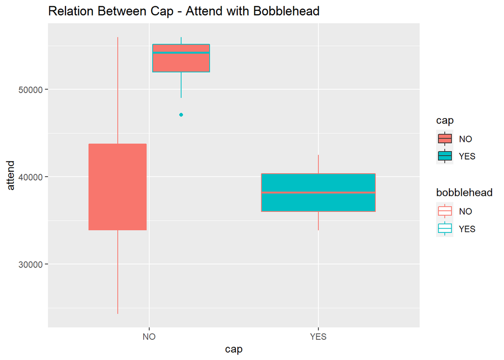

```r
cap_attend_bobblehead <- ggplot(dataSet, aes(cap, attend)) +
  geom_boxplot(aes(fill = cap, color = bobblehead)) +
  ggtitle("Relation Between Cap - Attend with Bobblehead")

cap_attend_bobblehead
```

### Exploring the Relation Between Day of Week - Attend and Bobblehead Promotion

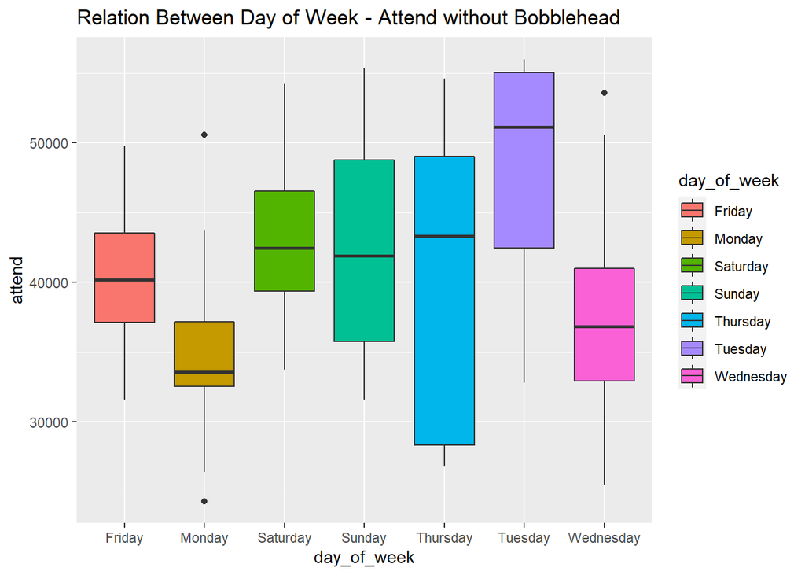

```r
day_of_week_attend <- ggplot(dataSet, aes(day_of_week, attend)) +
  geom_boxplot(aes(fill = day_of_week)) +
  ggtitle("Relation Between Day of Week - Attend without Bobblehead")

day_of_week_attend
```

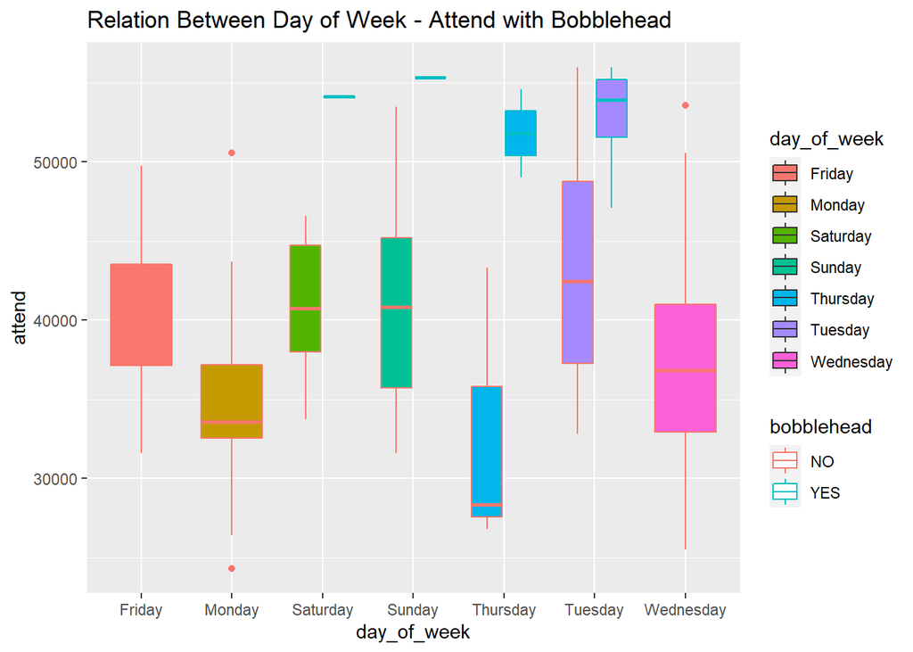

```r
day_of_week_attend_bobblehead <- ggplot(dataSet, aes(day_of_week, attend)) +
  geom_boxplot(aes(fill = day_of_week, color = bobblehead)) +
  ggtitle("Relation Between Day of Week - Attend with Bobblehead")

day_of_week_attend_bobblehead
```

### Exploring the Relation Between Day&Night - Attend and Bobblehead Promotion

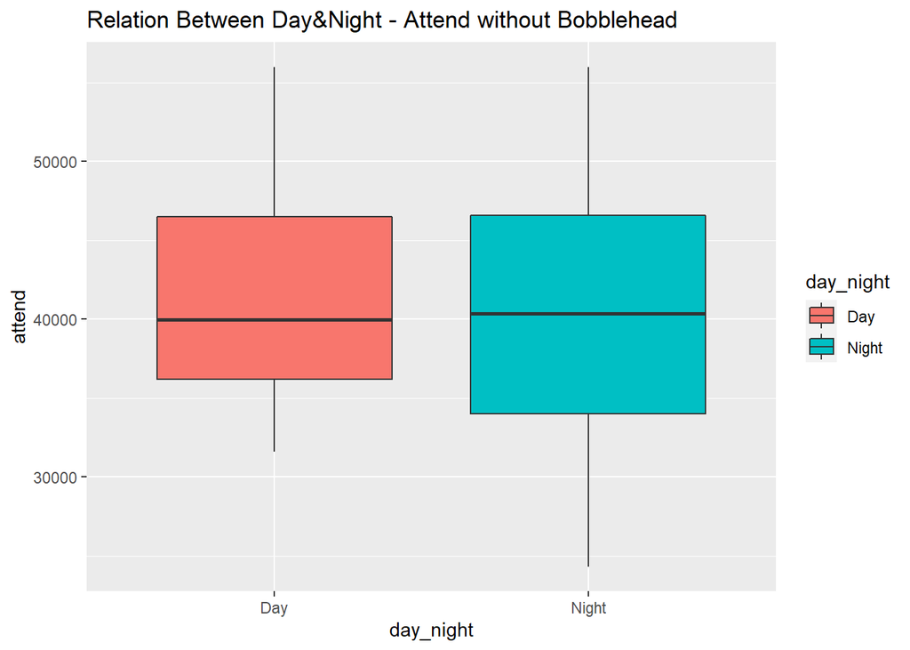

```r
day_night_attend <- ggplot(dataSet, aes(day_night, attend)) +
  geom_boxplot(aes(fill = day_night)) +
  ggtitle("Relation Between Day&Night - Attend without Bobblehead")

day_night_attend
```

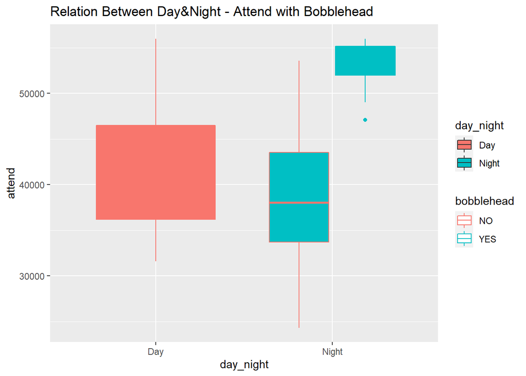

```r
day_night_attend_bobblehead <- ggplot(dataSet, aes(day_night, attend)) +
  geom_boxplot(aes(fill = day_night, color = bobblehead)) +
  ggtitle("Relation Between Day&Night - Attend with Bobblehead")

day_night_attend_bobblehead
```

### Exploring the Relation Between Temperature - Attend and Bobblehead Promotion

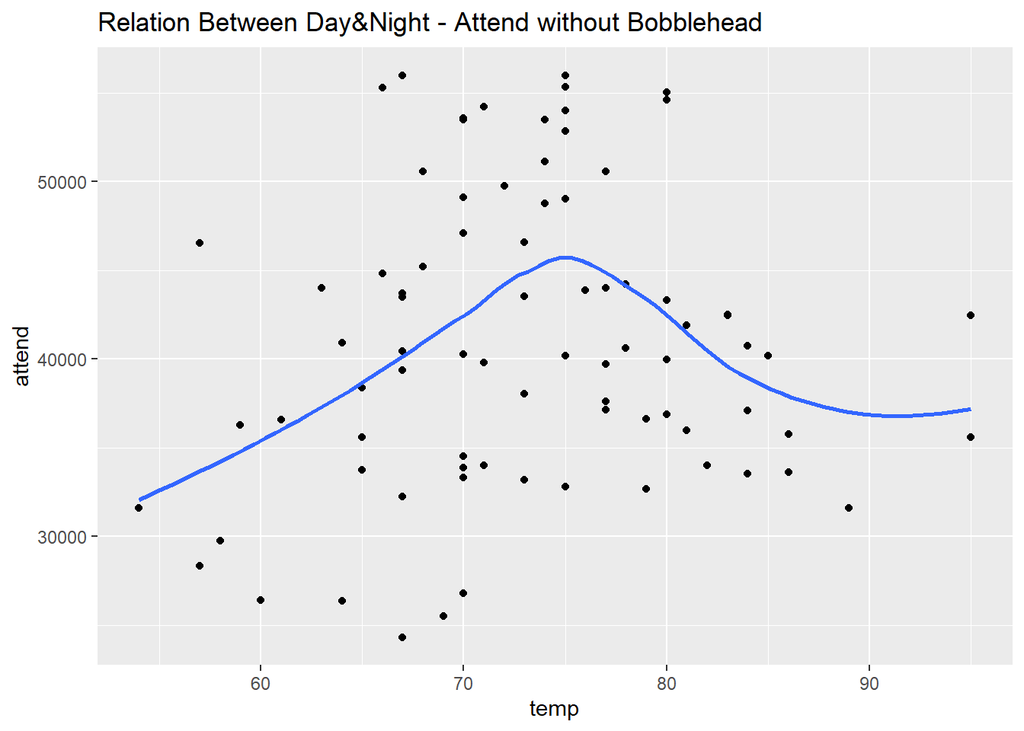

```r
temperature_attend <- ggplot(dataSet, aes(temp, attend)) +
  geom_point() +
  geom_smooth(se=FALSE) +
  ggtitle("Relation Between Day&Night - Attend without Bobblehead")

temperature_attend
```

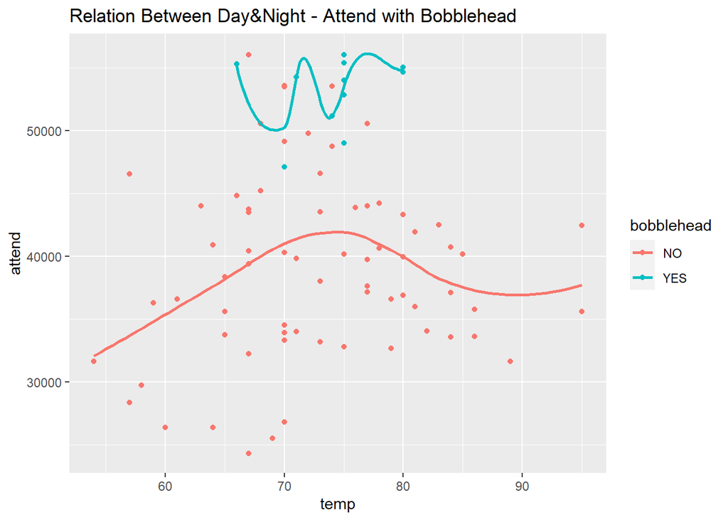

```r
temperature_attend_bobblehead <- ggplot(dataSet, aes(temp, attend, color = bobblehead)) +
  geom_point() +
  geom_smooth(se=FALSE) +
  ggtitle("Relation Between Day&Night - Attend with Bobblehead")

temperature_attend_bobblehead
```

### Pearson’s Chi Square Tests

```r
events %>%
  select(attend) %>%
  summary() %>%
  pander(caption = "Summary of attendance")
```

Summary of attendance

| attend |
| --- |
| Min. :24312 |
| 1st Qu.:34493 |
| Median :40284 |
| Mean :41040 |
| 3rd Qu.:46588 |
| Max. :56000 |

- The table above gives the clue about how we can decide the labels in the cut function down below. Total of 4 label is decided according to the min and max values of the table with the aim of keeping the datasets in the labels as large as possible. During the calculations, R Studio gives the following warning: “Chi-squared approximation may be incorrect”. In order to avoid this, we repeat the test using bootstrapping.

```r
cutEvents <- events %>%
  mutate(cutAttend = cut(attend, breaks = 4,
                     labels=c("Label1","Label2","Label3","Label4")))

panderOptions("table.split.table", Inf)
tbl2 <- xtabs(~ day_of_week+cutEvents$cutAttend, events)
tbl2 %>% summary %>% pander(caption="Pearson’s Chi-squared test for day_of_week")
```

Call: xtabs(formula = ~day_of_week + cutEvents$cutAttend, data = events) Number of cases in table: 81 Number of factors: 2

Pearson’s Chi-squared test for day_of_week

| Chisq | df | p.value |
| --- | --- | --- |
| 31.87 | 18 | 0.02277 |

Chi-squared approximation may be incorrect

```r
tbl2 %>% chisq.test(simulate.p.value = TRUE, B = 10000) %>% pander(caption = "Pearson's Chi-squared test with simulated p-value(based on 10000 replicates)")
```

Pearson’s Chi-squared test with simulated p-value(based on 10000 replicates)

| Test statistic | df | P value |
| --- | --- | --- |
| 31.87 | NA | 0.0213 * |

```r
panderOptions("table.split.table", Inf)
tbl2 <- xtabs(~ month+cutEvents$cutAttend, events)
tbl2 %>% summary %>% pander(caption="Pearson’s Chi-squared test for month")
```

Call: xtabs(formula = ~month + cutEvents$cutAttend, data = events) Number of cases in table: 81 Number of factors: 2

Pearson’s Chi-squared test for month

| Chisq | df | p.value |
| --- | --- | --- |
| 36.28 | 18 | 0.006499 |

Chi-squared approximation may be incorrect

```r
tbl2 %>% chisq.test(simulate.p.value = TRUE, B = 10000) %>% pander(caption = "Pearson's Chi-squared test with simulated p-value(based on 10000 replicates)")
```

Pearson’s Chi-squared test with simulated p-value(based on 10000 replicates)

| Test statistic | df | P value |
| --- | --- | --- |
| 36.28 | NA | 0.0048 * * |

```r
panderOptions("table.split.table", Inf)
tbl2 <- xtabs(~ day+cutEvents$cutAttend, events)
tbl2 %>% summary %>% pander(caption="Pearson’s Chi-squared test for day")
```

Call: xtabs(formula = ~day + cutEvents$cutAttend, data = events) Number of cases in table: 81 Number of factors: 2

Pearson’s Chi-squared test for day

| Chisq | df | p.value |
| --- | --- | --- |
| 83.65 | 90 | 0.6682 |

Chi-squared approximation may be incorrect

```r
tbl2 %>% chisq.test(simulate.p.value = TRUE, B = 10000) %>% pander(caption = "Pearson's Chi-squared test with simulated p-value(based on 10000 replicates)")
```

Pearson’s Chi-squared test with simulated p-value(based on 10000 replicates)

| Test statistic | df | P value |
| --- | --- | --- |
| 83.65 | NA | 0.7645 |

```r
panderOptions("table.split.table", Inf)
tbl2 <- xtabs(~ temp+cutEvents$cutAttend, events)
tbl2 %>% summary %>% pander(caption="Pearson’s Chi-squared test for temp")
```

Call: xtabs(formula = ~temp + cutEvents$cutAttend, data = events) Number of cases in table: 81 Number of factors: 2

Pearson’s Chi-squared test for temp

| Chisq | df | p.value |
| --- | --- | --- |
| 67.32 | 57 | 0.1648 |

Chi-squared approximation may be incorrect

```r
tbl2 %>% chisq.test(simulate.p.value = TRUE, B = 10000) %>% pander(caption = "Pearson's Chi-squared test with simulated p-value(based on 10000 replicates)")
```

Pearson’s Chi-squared test with simulated p-value(based on 10000 replicates)

| Test statistic | df | P value |
| --- | --- | --- |
| 67.32 | NA | 0.1378 |

```r
panderOptions("table.split.table", Inf)
tbl2 <- xtabs(~ skies+cutEvents$cutAttend, events)
tbl2 %>% summary %>% pander(caption="Pearson’s Chi-squared test for skies")
```

Call: xtabs(formula = ~skies + cutEvents$cutAttend, data = events) Number of cases in table: 81 Number of factors: 2

Pearson’s Chi-squared test for skies

| Chisq | df | p.value |
| --- | --- | --- |
| 6.002 | 3 | 0.1115 |

Chi-squared approximation may be incorrect

```r
tbl2 %>% chisq.test(simulate.p.value = TRUE, B = 10000) %>% pander(caption = "Pearson's Chi-squared test with simulated p-value(based on 10000 replicates)")
```

Pearson’s Chi-squared test with simulated p-value(based on 10000 replicates)

| Test statistic | df | P value |
| --- | --- | --- |
| 6.002 | NA | 0.1146 |

```r
panderOptions("table.split.table", Inf)
tbl2 <- xtabs(~ cap+cutEvents$cutAttend, events)
tbl2 %>% summary %>% pander(caption="Pearson’s Chi-squared test for cap")
```

Call: xtabs(formula = ~cap + cutEvents$cutAttend, data = events) Number of cases in table: 81 Number of factors: 2

Pearson’s Chi-squared test for cap

| Chisq | df | p.value |
| --- | --- | --- |
| 1.111 | 3 | 0.7743 |

Chi-squared approximation may be incorrect

```r
tbl2 %>% chisq.test(simulate.p.value = TRUE, B = 10000) %>% pander(caption = "Pearson's Chi-squared test with simulated p-value(based on 10000 replicates)")
```

Pearson’s Chi-squared test with simulated p-value(based on 10000 replicates)

| Test statistic | df | P value |
| --- | --- | --- |
| 1.111 | NA | 1 |

```r
panderOptions("table.split.table", Inf)
tbl2 <- xtabs(~ day_night+cutEvents$cutAttend, events)
tbl2 %>% summary %>% pander(caption="Pearson’s Chi-squared test for day_night")
```

Call: xtabs(formula = ~day_night + cutEvents$cutAttend, data = events) Number of cases in table: 81 Number of factors: 2

Pearson’s Chi-squared test for day_night

| Chisq | df | p.value |
| --- | --- | --- |
| 1.591 | 3 | 0.6614 |

Chi-squared approximation may be incorrect

```r
tbl2 %>% chisq.test(simulate.p.value = TRUE, B = 10000) %>% pander(caption = "Pearson's Chi-squared test with simulated p-value(based on 10000 replicates)")
```

Pearson’s Chi-squared test with simulated p-value(based on 10000 replicates)

| Test statistic | df | P value |
| --- | --- | --- |
| 1.591 | NA | 0.6623 |

```r
panderOptions("table.split.table", Inf)
tbl2 <- xtabs(~ opponent+cutEvents$cutAttend, events)
tbl2 %>% summary %>% pander(caption="Pearson’s Chi-squared test for opponent")
```

Call: xtabs(formula = ~opponent + cutEvents$cutAttend, data = events) Number of cases in table: 81 Number of factors: 2

Pearson’s Chi-squared test for opponent

| Chisq | df | p.value |
| --- | --- | --- |
| 79.51 | 48 | 0.002855 |

Chi-squared approximation may be incorrect

```r
tbl2 %>% chisq.test(simulate.p.value = TRUE, B = 10000) %>% pander(caption = "Pearson's Chi-squared test with simulated p-value(based on 10000 replicates)")
```

Pearson’s Chi-squared test with simulated p-value(based on 10000 replicates)

| Test statistic | df | P value |
| --- | --- | --- |
| 79.51 | NA | 0.0013 * * |

```r
panderOptions("table.split.table", Inf)
tbl2 <- xtabs(~ bobblehead+cutEvents$cutAttend, events)
tbl2 %>% summary %>% pander(caption="Pearson’s Chi-squared test for bobblehead")
```

Call: xtabs(formula = ~bobblehead + cutEvents$cutAttend, data = events) Number of cases in table: 81 Number of factors: 2

Pearson’s Chi-squared test for bobblehead

| Chisq | df | p.value |
| --- | --- | --- |
| 32.47 | 3 | 0.0000004161 |

Chi-squared approximation may be incorrect

```r
tbl2 %>% chisq.test(simulate.p.value = TRUE, B = 10000) %>% pander(caption = "Pearson's Chi-squared test with simulated p-value(based on 10000 replicates)")
```

Pearson’s Chi-squared test with simulated p-value(based on 10000 replicates)

| Test statistic | df | P value |
| --- | --- | --- |
| 32.47 | NA | 0.00009999 * * * |

```r
panderOptions("table.split.table", Inf)
tbl2 <- xtabs(~ shirt+cutEvents$cutAttend, events)
tbl2 %>% summary %>% pander(caption="Pearson’s Chi-squared test for shirt")
```

Call: xtabs(formula = ~shirt + cutEvents$cutAttend, data = events) Number of cases in table: 81 Number of factors: 2

Pearson’s Chi-squared test for shirt

| Chisq | df | p.value |
| --- | --- | --- |
| 3.956 | 3 | 0.2663 |

Chi-squared approximation may be incorrect

```r
tbl2 %>% chisq.test(simulate.p.value = TRUE, B = 10000) %>% pander(caption = "Pearson's Chi-squared test with simulated p-value(based on 10000 replicates)")
```

Pearson’s Chi-squared test with simulated p-value(based on 10000 replicates)

| Test statistic | df | P value |
| --- | --- | --- |
| 3.956 | NA | 0.2025 |

```r
panderOptions("table.split.table", Inf)
tbl2 <- xtabs(~ fireworks+cutEvents$cutAttend, events)
tbl2 %>% summary %>% pander(caption="Pearson’s Chi-squared test for fireworks")
```

Call: xtabs(formula = ~fireworks + cutEvents$cutAttend, data = events) Number of cases in table: 81 Number of factors: 2

Pearson’s Chi-squared test for fireworks

| Chisq | df | p.value |
| --- | --- | --- |
| 1.846 | 3 | 0.6049 |

Chi-squared approximation may be incorrect

```r
tbl2 %>% chisq.test(simulate.p.value = TRUE, B = 10000) %>% pander(caption = "Pearson's Chi-squared test with simulated p-value(based on 10000 replicates)")
```

Pearson’s Chi-squared test with simulated p-value(based on 10000 replicates)

| Test statistic | df | P value |
| --- | --- | --- |
| 1.846 | NA | 0.6538 |

### Regress Attendance on All Variables

```r
res <- lm(attend ~ ., events)
res
```

```
##
## Call:
## lm(formula = attend ~ ., data = events)
##
## Coefficients:
##          (Intercept)              monthMAY              monthJUN
##             49144.43               4562.82              -2780.38
##             monthJUL              monthAUG              monthSEP
##              4725.36               8631.58               4296.83
##             monthOCT                   day    day_of_weekTuesday
##              6217.53                134.00               8670.34
## day_of_weekWednesday   day_of_weekThursday     day_of_weekFriday
##                 6.94                460.46             -18358.17
##  day_of_weekSaturday     day_of_weekSunday        opponentAstros
##              3674.93                892.73             -20678.17
##       opponentBraves       opponentBrewers     opponentCardinals
##            -18497.20             -22322.21             -12532.09
##         opponentCubs        opponentGiants       opponentMarlins
##            -10529.08             -16880.09             -19147.75
##         opponentMets     opponentNationals        opponentPadres
##             -4234.12              -5850.86             -11169.54
##     opponentPhillies       opponentPirates          opponentReds
##            -13698.94             -12451.05             -16473.41
##      opponentRockies        opponentSnakes     opponentWhite Sox
##            -16964.63             -19919.33               -928.32
##                 temp           skiesCloudy        day_nightNight
##               -43.20               -114.01              -3662.30
##               capYES              shirtYES          fireworksYES
##             -6503.20                949.27              20200.13
##           bobblehead
##              9395.63
```

```r
small <- update(res, . ~ 1) #res is original model, ~ means intersection
anova(small, res) #comparation
```

```
## Analysis of Variance Table
##
## Model 1: attend ~ 1
## Model 2: attend ~ month + day + day_of_week + opponent + temp + skies +
##     day_night + cap + shirt + fireworks + bobblehead
##   Res.Df        RSS Df  Sum of Sq      F    Pr(>F)
## 1     80 5507932888
## 2     44 1572693825 36 3935239063 3.0583 0.0002485 ***
## ---
## Signif. codes:  0 '***' 0.001 '**' 0.01 '*' 0.05 '.' 0.1 ' ' 1
```

*In anova table, if small model is correct, then we expect p-value to be large (>=.05). As it can be seen from the above table p-value (0.0002485) is very small, hence we reject this small model meaning that the sample is still providing some information.